# Homework 04 - HPC and ML 2

Sophie Xu

March 28, 2025

### Introduction

This assignment aims to develop proficiency in high-performance computing (HPC) and machine learning (ML). The first section focuses on parallel computing, while the second applies five different models to analyze the Baseball Hitter Stats and Salary dataset.

### 1 Parallel Computing

1.1 The alternative functions in the following code utilize built-in matrix and vector computation methods to enhance execution speed. Table. 1 demonstrates that the alternative functions consistently outperform the original version across all performance metrics.

```r
# Total Sum by Row
fun1 <- function(mat) {
  n <- nrow(mat)
  ans <- double(n)
  for (i in 1:n) {
    ans[i] <- sum(mat[i, ])
  }
  ans
}

fun1alt <- function(mat) {
  # YOUR CODE HERE
  rowSums(mat)
}

# Cumulative Sum by Row
fun2 <- function(mat) {
  n <- nrow(mat)
  k <- ncol(mat)
  ans <- mat
  for (i in 1:n) {
    for (j in 2:k) {
      ans[i,j] <- mat[i, j] + ans[i, j - 1]
    }
  }
  ans
}

fun2alt <- function(mat) {
  # YOUR CODE HERE
  t(apply(mat, 1, cumsum))
}

# Use the data with this code
set.seed(2315)
dat <- matrix(rnorm(200 * 100), nrow = 200)

# Benchmarking
results <- microbenchmark(
  fun1(dat),
  fun1alt(dat),
  fun2(dat),
  fun2alt(dat),
  unit = "ms"
)
kable(summary(results), digits = 2, format = "markdown",
      caption = "Table. 1 Run time comparison of functions with or without vectorization. Units are in milliseconds.")
```

Table. 1 Run time comparison of functions with or without vectorization. Units are in milliseconds.

| expr | min | lq | mean | median | uq | max | neval |
| --- | --- | --- | --- | --- | --- | --- | --- |
| fun1(dat) | 0.23 | 0.29 | 0.43 | 0.32 | 0.41 | 7.24 | 100 |
| fun1alt(dat) | 0.05 | 0.06 | 0.10 | 0.06 | 0.08 | 2.42 | 100 |
| fun2(dat) | 1.54 | 1.71 | 2.25 | 1.85 | 2.37 | 10.40 | 100 |
| fun2alt(dat) | 0.48 | 0.79 | 1.46 | 0.91 | 1.18 | 15.76 | 100 |

1.2 (a) The following code performs Monte Carlo estimation of $\pi$ for different sample sizes. For varying sample sizes ($10^3$, $10^5$, $10^6$), the estimated values are 3.060000, 3.142400, and 3.144412, respectively. As the sample size increases, the estimate becomes more accurate; however, runtime also scales proportionally (e.g., by a factor of $10^2$, $10^1$).

```r
# MC Estimation
estimate_pi <- function(N) {
  points <- matrix(runif(2 * N), ncol = 2)
  inside_circle <- sum(rowSums(points^2) <= 1)
  4 * inside_circle / N
}

# Simulation
N_values <- c(1000, 100000, 1000000)
pi_estimates <- sapply(N_values, estimate_pi)
#print(pi_estimates)

# Benchmarking
results <- microbenchmark(
  estimate_pi(1000),
  estimate_pi(100000),
  estimate_pi(1000000),
  unit = "ms"
)
kable(summary(results), digits = 2, format = "markdown",
      caption = "Table. 2 Run time comparison of Monte Carlo Estimation of Pi with varying sample sizes (10^3 vs 10^5 vs 10^6). Units are in milliseconds.")
```

Table. 2 Run time comparison of Monte Carlo Estimation of Pi with varying sample sizes (10^3 vs 10^5 vs 10^6). Units are in milliseconds.

| expr | min | lq | mean | median | uq | max | neval |
| --- | --- | --- | --- | --- | --- | --- | --- |
| estimate_pi(1000) | 0.04 | 0.07 | 0.09 | 0.09 | 0.11 | 0.24 | 100 |
| estimate_pi(1e+05) | 3.87 | 5.12 | 9.09 | 6.08 | 7.72 | 187.80 | 100 |
| estimate_pi(1e+06) | 67.16 | 78.28 | 90.36 | 81.56 | 87.27 | 251.90 | 100 |

Table. 3 confirms that the parallel mode is faster than the serial mode, leveraging four cores to execute tasks simultaneously. Dividing the total runtime in serial mode by 5,000 yields an average runtime similar to the result shown in Table 2. This suggests that running the simulation 5,000 times with a sample size of $10^6$ would likely scale in the same manner as before, meaning the serial runtime would increase by a factor of 10. Similarly, we can estimate that the runtime with a sample size of $10^6$ in parallel mode will also increase by a factor of 10, but it will still be faster than the serial mode due to the lower average runtime per simulation in parallel mode. The plot further supports this observation, showing that the mean parallel runtime is lower than the serial runtime.

Table. 3 Serial versus parallel run times of Monte Carlo Estimation of Pi. Units are in milliseconds.

| expr | min | lq | mean | median | uq | max | neval |
| --- | --- | --- | --- | --- | --- | --- | --- |
| serial | 35251.45 | 35292.20 | 35790.15 | 35630.84 | 36254.05 | 36522.21 | 5 |
| parallel | 20339.18 | 22388.22 | 23442.69 | 23482.30 | 25071.84 | 25931.88 | 5 |

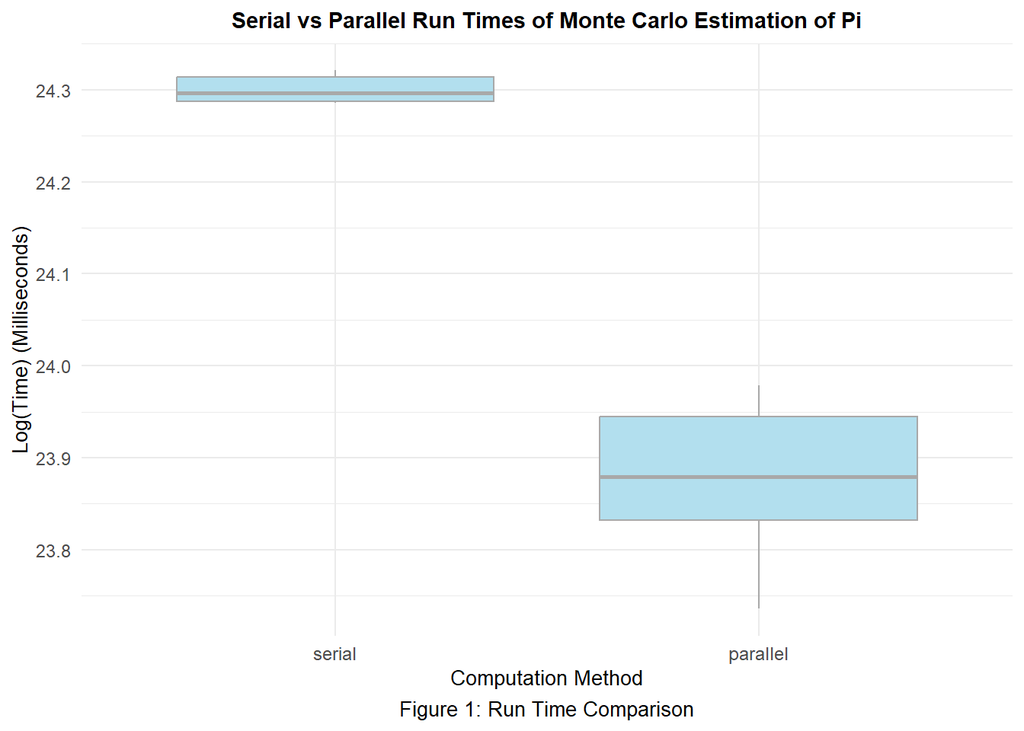

### 2 Machine Learning

This section applies machine learning to the hitters dataset, which includes 332 observations of major league baseball players and 20 variables, with `Salary` as the response variable. Initially, the dataset is preprocessed by removing entries with missing values in `Salary` and converting character variables into factors. The dataset is then split into 70% training and 30% testing subsets.

2.1 The first model is a regression tree. The optimal complexity parameter ($\approx 0.0383$) is identified, and the tree is pruned, resulting in an Out-of-Bag (OOB) error of approximately $0.5375$. The visualized tree indicates that `CHits`, `CAtBat`, `RBI`, `AtBat`, `CHmRun`, `PutOuts`, and `CRBI` are the most influential predictors.

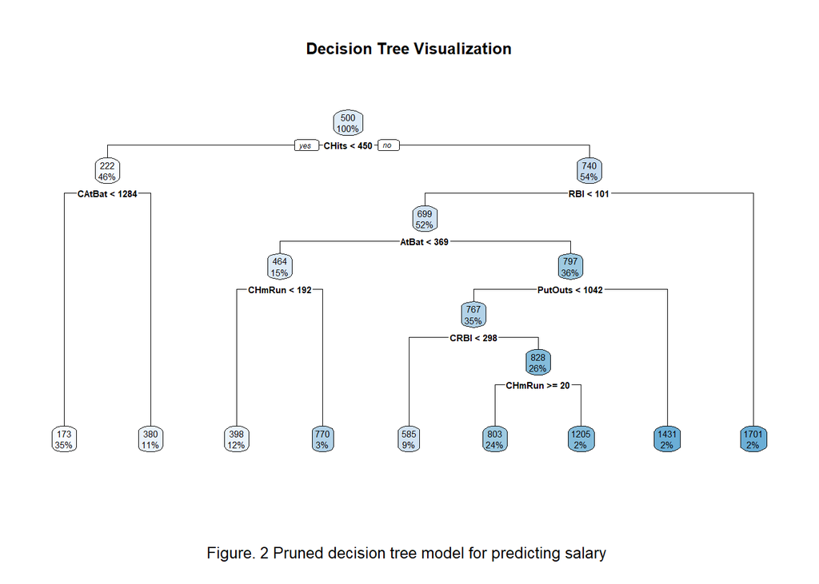

2.2 The second model is a bagging approach, yielding an OOB Mean Squared Error (MSE) $\approx 83,109.5485$ and OOB $R^2 \approx 0.5556$. The variable importance plot reveals that the top predictors are similar to those in the regression tree, but ranked differently. For instance, CRBI has the highest increase in node purity but was not the first node in the regression tree.

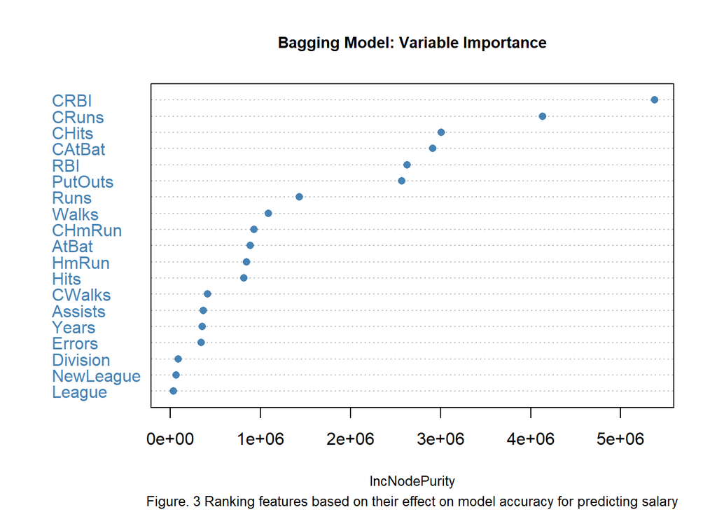

2.3 The third model is a random forest, which produces an OOB MSE $\approx 84,597.0298$ and OOB $R^2 \approx 0.5476$. The variable importance plot again aligns closely with the regression tree and bagging model. However, the distribution differs: in the bagging model, the top six variables stand out significantly, whereas in the random forest, only the top four are distinctly separated, with the rest increasing in node purity at a steadier rate.

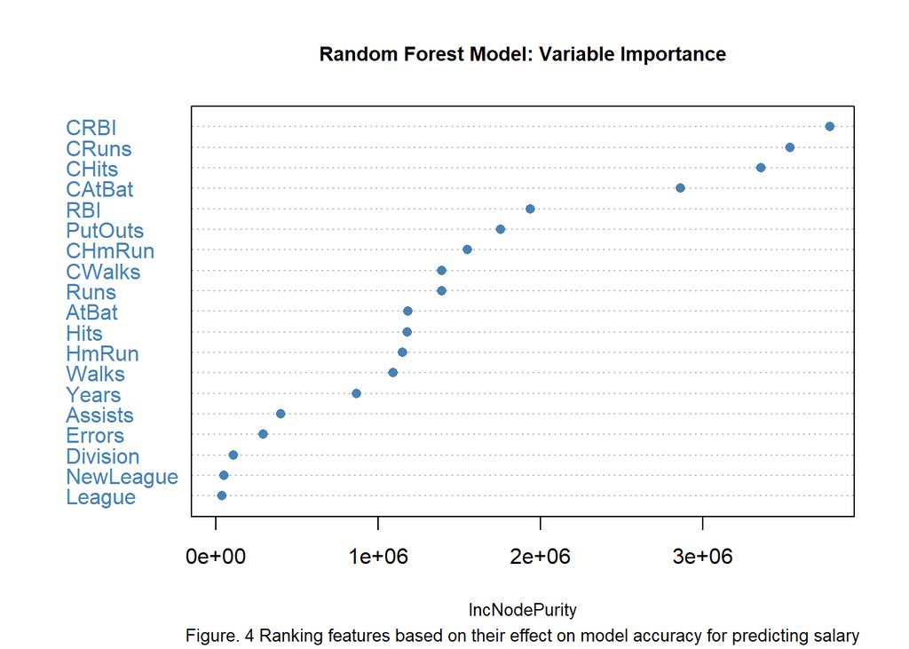

2.4 The fourth model is a boosting approach with 1,000 trees, where the learning rate ($\lambda$) is tuned. The plot shows that training MSE converges as $\lambda$ approaches 0.5, with a substantial reduction from over 75,000 MSE, underscoring the importance of tuning $\lambda$.

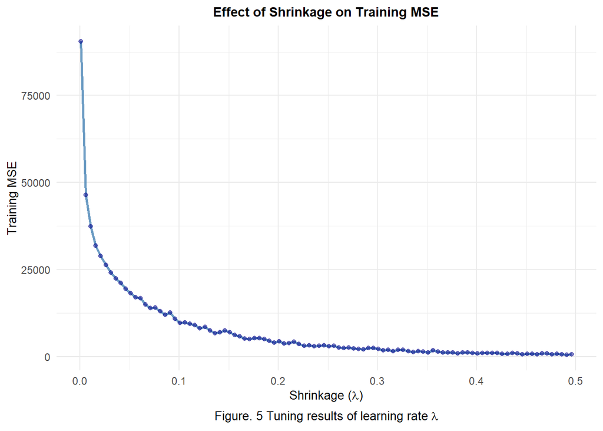

The variable importance plot employs a different metric, making direct comparison difficult, but it highlights new influential variables such as Hits, CWalks, and Walks, which were not as prominent in previous models.

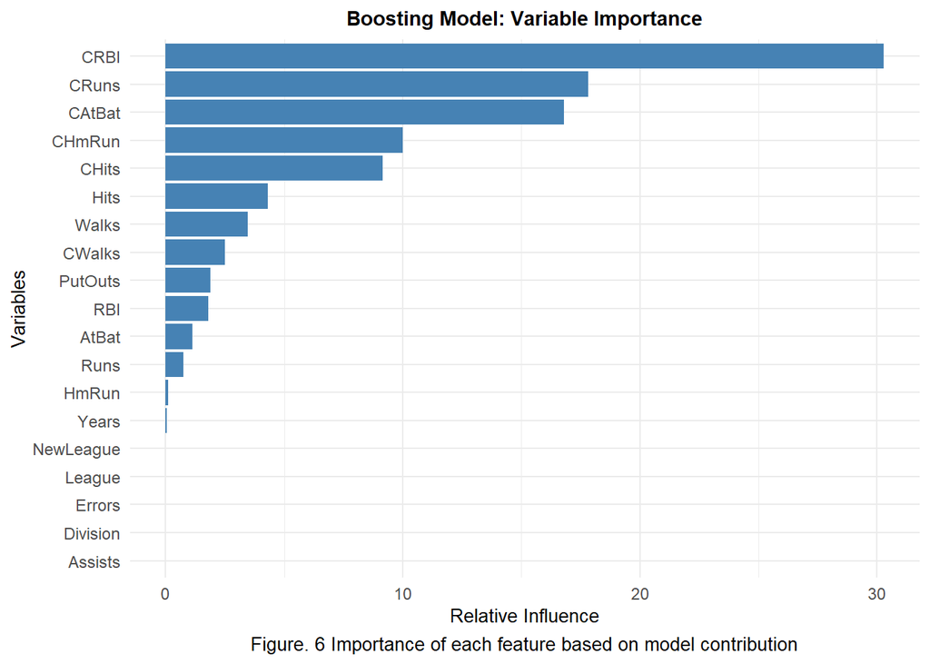

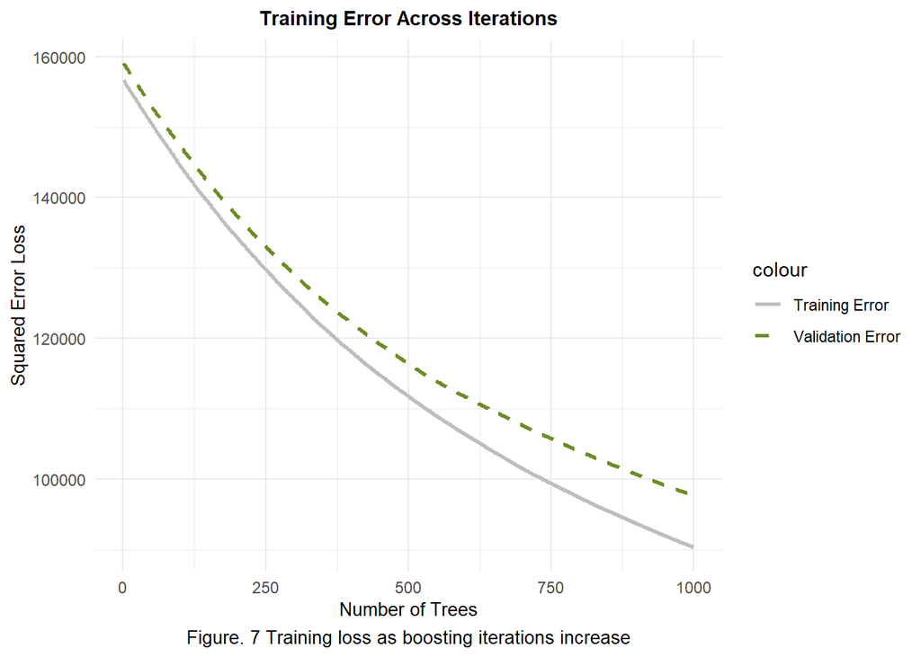

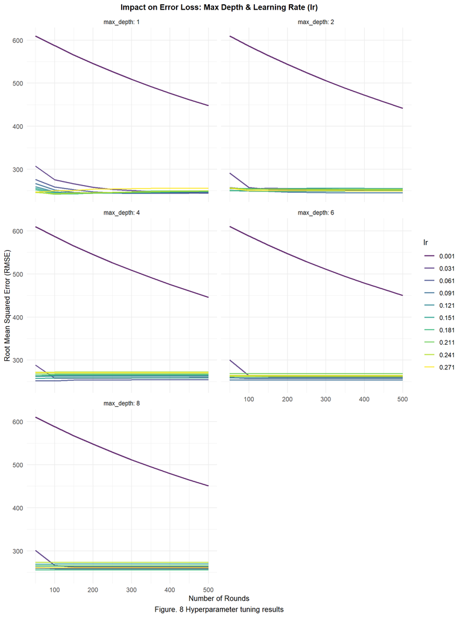

The variable importance plot reveals differences from prior models, with Years emerging as a key predictor, despite its absence from previous top rankings.

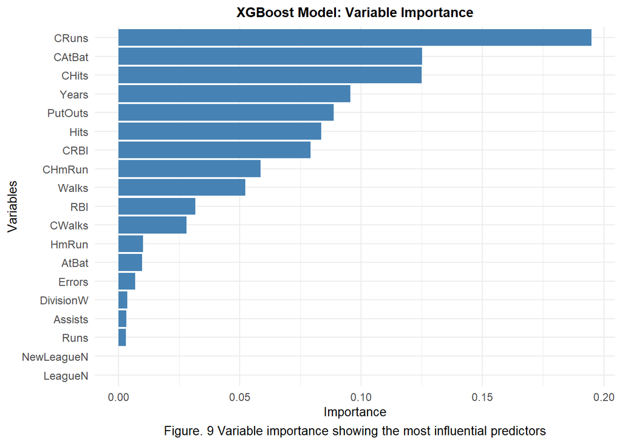

2.6 The table below presents RMSE and $R^2$ results on the test set, ranking model performance: Bagging > Random Forest > XGBoost > Regression Tree > Boosting. Given its comparable accuracy and lower computational cost, the bagging model is the most effective choice.

Table. 4 Model Performance Comparison

| Model | RMSE | R_Squared |
| --- | --- | --- |
| Decision Tree | 401.1571 | 0.4633 |
| Bagging | 348.1341 | 0.5958 |
| Random Forest | 350.2422 | 0.5909 |
| Boosting | 476.9775 | 0.2413 |
| XGBoost | 360.3119 | 0.5670 |

Notably, the boosting model performs significantly worse than others, likely due to its variable selection. While regression trees, bagging, and random forests share a similar top predictor set, boosting introduces Hits, CWalks, and Walks, which may not be optimal. XGBoost incorporates fewer new variables and optimizes more hyperparameters, possibly explaining its superior performance compared to boosting.

### Conclusion

This assignment demonstrated the benefits of parallel computing in speeding up computations and improving efficiency. In machine learning, bagging and random forest outperformed other models, while boosting underperformed due to suboptimal variable selection. Parallel computing was also crucial for accelerating hyperparameter tuning in XGBoost. Overall, leveraging parallelization enhances both computational speed and model optimization in data-driven tasks.